# 2 A tour of R

### 2.2.4 Data frames and tibbles

A data frame is a list whose components are vectors with the same length. As data frames are a special class of lists you they can hold heterogeneous components (numeric, date/time, string, boolean values). Unlike like lists (but like matrices), the components of a data frame have the same length. As a result, they are very useful to store variables that measure a property for various observations: with one observation per row and one variable per column, a data frame looks like a matrix with *n* observation and *m* variables. However, unlike a matrix, these variables do not have to share a common type: one variable can be a character variable, the other a date/time variable while yet other variables are double of integer variables.

Most data frames that you will use will be imported from e.g. an excel spreadsheet, a database or through an API. The functions that we will cover to show you how you can do so return a data frame. However, for some applications you’ll also need to create your own data frame.

To create a data frame, R includes the function `data.frame()`. Within the round brackets, you add the name of the variable and its values as a vector. A small data frame including the first 5 months of the year (variable `month`) as well as the number of days in that month (variable `days`) is created using

```r
my_df <- data.frame(month = c("Jan", "Feb", "Mar", "Apr", "May"), days = c(31, 28, 31, 30, 31))
```

In the environment pane, you can see that the data frame `my_df` has 5 observations with 2 variables for each observation. As with lists, the arrow before the name can be used to show additional information: the name and type of the variables as well as the first observations. Because a data frame is a special class of type list, you can use all subsetting operations that where shown for lists, e.g.

- return the first variable as a list:

```r
my_df[1]
```

```
  month
1   Jan
2   Feb
3   Mar
4   Apr
5   May
```

- return the second variable as a vector (of numeric variables):

```r
my_df[[2]]
```

```
[1] 31 28 31 30 31
```

```r
my_df$days
```

```
[1] 31 28 31 30 31
```

- to select all values for all variables for the second to fourth observation:

```r
my_df[2:4, ]
```

```
  month days
2   Feb   28
3   Mar   31
4   Apr   30
```

- to select all values for the first and fourth observations:

```r
my_df[c(1, 4), ]
```

```
  month days
1   Jan   31
4   Apr   30
```

To add a variable to a data frame which is calculated from the values of other variables, we will use {dplyr}’s `mutate()` function in Chapter 8. An alternative is to add a variable as we did with lists. For instance, to calculate the number of hours per month, the latter approach uses the following code:

```r
my_df$hours <- my_df$days * 24
```

As an illustration, using {dplyr}’s `mutate()` function to calculate the number of seconds per month

```r
my_df <- dplyr::mutate(my_df, seconds = hours * 60)
```

In this code, we use `dplyr::` as this package isn’t loaded into the memory. To use the function, we have to add a reference to the package where the function can be found. If the package would have been loaded, the part `dplyr::` would not have been necessary.

You can order a data frame using base R’s `order()` function. Here too, {dplyr} includes a function that does the same operation. To illustrate the former, let’s sort `my_df` in ascending order for the number of days per year:

```r
my_df[order(my_df$days), ]
```

```
  month days hours seconds
2   Feb   28   672   40320
4   Apr   30   720   43200
1   Jan   31   744   44640
3   Mar   31   744   44640
5   May   31   744   44640
```

Using {dplyr}:

```r
dplyr::arrange(my_df, days)
```

```
  month days hours seconds
1   Feb   28   672   40320
2   Apr   30   720   43200
3   Jan   31   744   44640
4   Mar   31   744   44640
5   May   31   744   44640
```

R includes sample data frames. To illustrate the use of a larger data frame than `my_df`, we’ll use `mtcars`, a data frame that includes fuel efficiency and other characteristics for 32 cars. You can see the full data frame using `Vieuw(mtcars)`. This function openens a new tab in the source pane where you view the full data frame. Using the arrows on the right of the variable names, you can sort that data frame ascending or descending. Often, you’ll want to look at a subset of the data. To do so, you can use the `head()` or `tail()` function. The first shows the first 6 observations, the second the last 6 observations. You can add more variable, but here we’ll keep the default value and ask R to show 6 observations. Let’s look at the first six observations:

```r
head(mtcars)
```

```
                   mpg cyl disp  hp drat    wt  qsec vs am gear carb
Mazda RX4         21.0   6  160 110 3.90 2.620 16.46  0  1    4    4
Mazda RX4 Wag     21.0   6  160 110 3.90 2.875 17.02  0  1    4    4
Datsun 710        22.8   4  108  93 3.85 2.320 18.61  1  1    4    1
Hornet 4 Drive    21.4   6  258 110 3.08 3.215 19.44  1  0    3    1
Hornet Sportabout 18.7   8  360 175 3.15 3.440 17.02  0  0    3    2
Valiant           18.1   6  225 105 2.76 3.460 20.22  1  0    3    1
```

The last six observations are shown using

```r
tail(mtcars)
```

```
                mpg cyl  disp  hp drat    wt qsec vs am gear carb
Porsche 914-2  26.0   4 120.3  91 4.43 2.140 16.7  0  1    5    2
Lotus Europa   30.4   4  95.1 113 3.77 1.513 16.9  1  1    5    2
Ford Pantera L 15.8   8 351.0 264 4.22 3.170 14.5  0  1    5    4
Ferrari Dino   19.7   6 145.0 175 3.62 2.770 15.5  0  1    5    6
Maserati Bora  15.0   8 301.0 335 3.54 3.570 14.6  0  1    5    8
Volvo 142E     21.4   4 121.0 109 4.11 2.780 18.6  1  1    4    2
```

You can look at other observations using by e.g. subsetting the data frame. For instance, the 20th to 25th observations are

```r
mtcars[20:25, ]
```

```
                  mpg cyl  disp  hp drat    wt  qsec vs am gear carb
Toyota Corolla   33.9   4  71.1  65 4.22 1.835 19.90  1  1    4    1
Toyota Corona    21.5   4 120.1  97 3.70 2.465 20.01  1  0    3    1
Dodge Challenger 15.5   8 318.0 150 2.76 3.520 16.87  0  0    3    2
AMC Javelin      15.2   8 304.0 150 3.15 3.435 17.30  0  0    3    2
Camaro Z28       13.3   8 350.0 245 3.73 3.840 15.41  0  0    3    4
Pontiac Firebird 19.2   8 400.0 175 3.08 3.845 17.05  0  0    3    2
```

To view one variable, e.g. `mpg`:

```r
mtcars$mpg
```

```
 [1] 21.0 21.0 22.8 21.4 18.7 18.1 14.3 24.4 22.8 19.2 17.8 16.4 17.3 15.2 10.4
[16] 10.4 14.7 32.4 30.4 33.9 21.5 15.5 15.2 13.3 19.2 27.3 26.0 30.4 15.8 19.7
[31] 15.0 21.4
```

To see the observations with the smallest or largest values on one variable, you can use `head()` or `tail()` on the ordered data frame. For instance, the observations with the smallest values for `disp` are

```r
head(mtcars[order(mtcars$dis), ])
```

```
                mpg cyl  disp  hp drat    wt  qsec vs am gear carb
Toyota Corolla 33.9   4  71.1  65 4.22 1.835 19.90  1  1    4    1
Honda Civic    30.4   4  75.7  52 4.93 1.615 18.52  1  1    4    2
Fiat 128       32.4   4  78.7  66 4.08 2.200 19.47  1  1    4    1
Fiat X1-9      27.3   4  79.0  66 4.08 1.935 18.90  1  1    4    1
Lotus Europa   30.4   4  95.1 113 3.77 1.513 16.90  1  1    5    2
Datsun 710     22.8   4 108.0  93 3.85 2.320 18.61  1  1    4    1
```

while these with the largest values can be seen from

```r
tail(mtcars[order(mtcars$dis), ])
```

```
                     mpg cyl disp  hp drat    wt  qsec vs am gear carb
Hornet Sportabout   18.7   8  360 175 3.15 3.440 17.02  0  0    3    2
Duster 360          14.3   8  360 245 3.21 3.570 15.84  0  0    3    4
Pontiac Firebird    19.2   8  400 175 3.08 3.845 17.05  0  0    3    2
Chrysler Imperial   14.7   8  440 230 3.23 5.345 17.42  0  0    3    4
Lincoln Continental 10.4   8  460 215 3.00 5.424 17.82  0  0    3    4
Cadillac Fleetwood  10.4   8  472 205 2.93 5.250 17.98  0  0    3    4
```

Let’s now add a variable kilometers per liter `kml` as the product of miles per gallon `mpg` and 0.4251. To do so, we create a new variable to add to the data frame and assign it the value mpg * 0.4251:

```r
mtcars$kml <- mtcars$mpg * 0.4251
```

In the environment pane, you can see that the data frame `mtcars` includes this new variable `kml`.

Tibbles and data frames are close siblings. Tibbles are data structures introduced with the tidyverse collection of packages ({dplyr}, {stringr}, …). Working with tibbles requires the {tibble} package. Tibbles are more consistent relative to base R’s data frames. To illustrate a couple of differences, let’s use `mtcars_df` and `mtcars_tib` the tibble version of the data frame:

```r
mtcars_df <- mtcars
mtcars_tib <- tibble::tibble(mtcars)
```

If you print a data frame, R shows all observations and tries to show all columns. Printing a tibble only shows the first 10 observations and only the columns that fit on your screen. You can see this if you type `mtcars_df` and `mtcars_tib` in the console. If you look at the output in the console, you’ll also see that a tibble includes the column type below the name of the column. This is not the case for the data frame. Here, you have to use `str()` to see the column types.

Data frames allow for partial matching of variable names. The dataset includes a variable `mpg` but no variable `m`. Yet, `mtcars_df$m` will show `mtcars_df$mpg` as output. A tibble does not allow partial matching:

```r
mtcars_df$m
```

```
 [1] 21.0 21.0 22.8 21.4 18.7 18.1 14.3 24.4 22.8 19.2 17.8 16.4 17.3 15.2 10.4
[16] 10.4 14.7 32.4 30.4 33.9 21.5 15.5 15.2 13.3 19.2 27.3 26.0 30.4 15.8 19.7
[31] 15.0 21.4
```

shows prints output, while

```r
mtcars_tib$m
```

[output not shown]

shows an error.

As a result, tibbles are more predictable as you can’t use variables in a dataset that you didn’t meant to use. There are some other differences and we”ll cover them in Chapter 3 but for now, we’ll mostly work with data frames.

**CautionYour turn**

Create a data frame `df1` with 3 variables: - units: a sample with size 100 taken with replacement from the sequence 1:12 (`sample(x = 1:12, size = 100, replace = TRUE)`) - revenue: 100 draws from a normal distribution with mean 100 and standard deviation 10 (`rnorm(n = 100, mean = 100, sd = 10)`) - customer: a sample with size 100 taken with replacement from the first 5 letters of the alphabet in uppercase (`sample(x = LETTERS[1:5], size = 100, replace = TRUE)`)

```r
df1 <- data.frame(
  units = sample(x = 1:12, size = 100, replace = TRUE),
  revenue = rnorm(n = 100, mean = 100, sd = 10),
  customer = sample(x = LETTERS[1:5], size = 100, replace = TRUE))
```

Can you identify the structure of `df1`?

```r
str(df1)
```

```
'data.frame':   100 obs. of  3 variables:
 $ units   : int  2 12 2 8 1 2 7 9 10 9 ...
 $ revenue : num  98 86.7 93.2 88.4 110.4 ...
 $ customer: chr  "D" "B" "B" "A" ...
```

Show the first 6 observations from `df1` in the console.

```r
head(df1)
```

```
  units   revenue customer
1     2  98.01789        D
2    12  86.68543        B
3     2  93.22168        B
4     8  88.41431        A
5     1 110.39588        A
6     2  86.37223        A
```

Show the last 6 observations from `df1` in the console

```r
tail(df1)
```

```
    units   revenue customer
95      2 112.22640        E
96      2 111.62490        C
97      7  98.93194        E
98     12  90.11461        D
99      7 104.93028        B
100     6  91.48980        E
```

Extract the variable `revenue` from `df1` and assign the outcome to a vector `vec_rev`. How many ways can you identify to perform this operation?

```r
vec_rev <- df1$revenue

# Alternative (data frames are lists)
# vec_rev <- df1[[2]]
# vec_rev <- df1[["revenue"]]
```

Calculate the mean of the revenue variable in `df1`

```r
mean(df1$revenue)
```

```
[1] 99.42524
```

Change the customer variable in `df1` from uppercase to lowercase (make sure to reassign the value).

```r
df1$customer <- tolower(df1$customer)
```

Add a variable, `price`, as the result of the division of `revenue` and `units`.

```r
df1$price <- df1$revenue / df1$units
```

Using {dplyr}’s `mutate()` function, would you be able to rewrite the previous code but assign the result to `price2`?

```r
df1 <- dplyr::mutate(df1, price2 = revenue/units)
```

Create a tibble from `df1` and assing it to `tb1` (note you need to add `tibble::` before the function as the tibble package was not loaded in the memory).

```r
tb1 <- tibble::tibble(df1)
```

Try to spot the difference between `tb1` and `df1`. In the console type `df1` and compare the output with the case where you type `tb1`.

```r
head(df1[order(df1$price), ])
```

```
   units  revenue customer    price   price2
2     12 86.68543        b 7.223786 7.223786
98    12 90.11461        d 7.509550 7.509550
11    12 95.70917        a 7.975764 7.975764
65    11 89.32934        e 8.120849 8.120849
55    11 90.99922        a 8.272657 8.272657
30    12 99.41816        c 8.284847 8.284847
```

## 2.3 Functions

Base R includes many build in functions. In the previous section, we already used a couple of them, e.g. `sample()`, `rnorm()`, `mean()`, `paste()`, `order()`, `vector()`, `matrix()`, `list()`, … . In addition to these build in base R functions, packages include functions that extend the capabilities of R. Examples that we have used so far include `dplyr::mutate()` or `dplyr::arrange()`. R further allows you to write your own function. In this section, we’ll introduce functions and show how you can find help for each of them. This section further shows how you can write your own function.

### 2.3.1 Build in functions: base R and packages

To introduce functions, we’ll use the function `mean()`. To find help for this function you can type use `help(mean)` or add a question mark `?` before the name of the function in the console. This line will open the help pane on the lower right hand side. To find help for the `mean()` function, you can type

```r
?mean()
help(mean)
```

in the console. On the right, you’ll see the help file for this function

Figure 2.1: Help for the function mean()

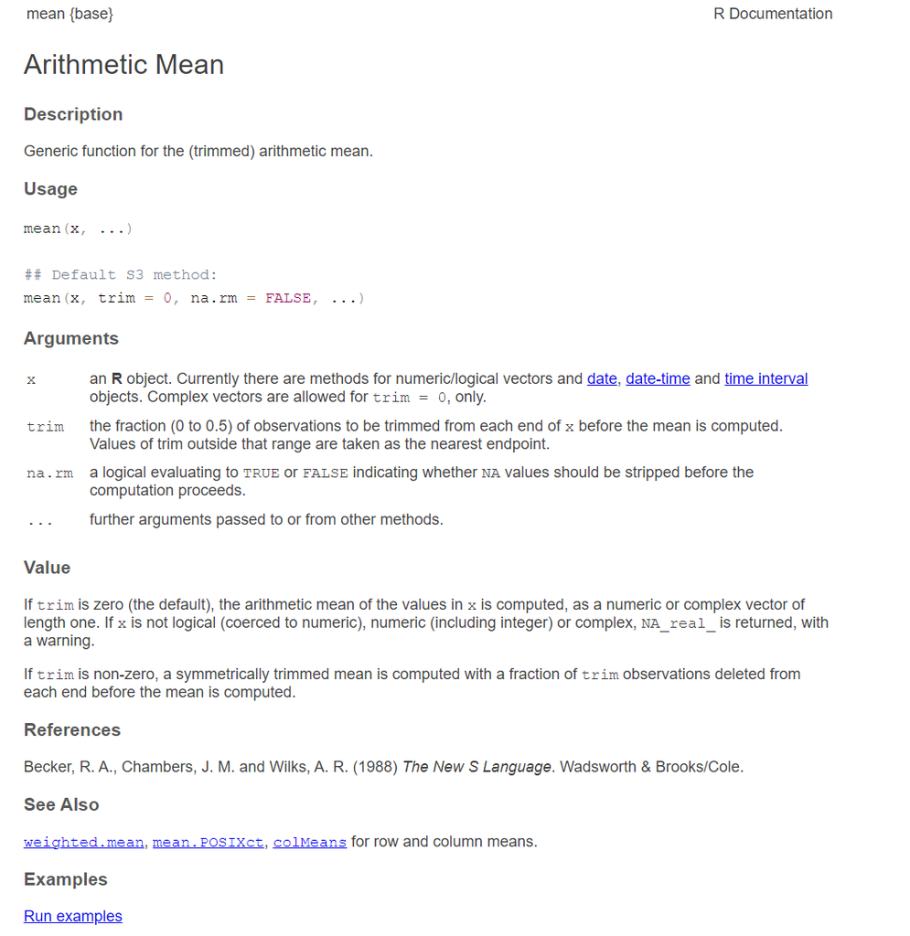

There are a couple of ways to use these arguments. To illustrate them, we’ll use two numeric vectors, one with missing values `vec_num` and one without missing values (`vec_num_nona`)

```r
vec_num <- c(0.0001, 0.0005, NA, 1000, 1500, NA, seq(from = 1, to = 4, by = 1))
vec_num_nona <- c(0.0001, 0.0005, 1000, 1500, seq(from = 1, to = 4, by = 1))
```

The first way to use this function is to name the arguments and add their value. This is also called name matching. Suppose that you want to calculate the mean of `vec_num` for all observations after removing missing values, you would include the name of the vector after the object argument, `x = vec_num`, use `trim = 0` (use all vaues) and set `na.rm = TRUE` (eliminate missing values from the calculation):

```r
mean(x = vec_num, trim = 0, na.rm = TRUE)
```

```
[1] 313.7501
```

Note that in this case, we didn’t use the assignment operator `<-` but the equality character `=`: we don’t want to assign the value of `vec_num` to a variable `x` nor do we want to assign the value of `0` to the variable `trim`. What we want is R to know that the object whose mean we want to calculate is `vec_num` (`x = vec_num`), that we don’t want to eliminate extreme observations from the dataset (`trim = 0`) and that we want to compute the mean after removing missing values (`na.rm = TRUE`). After R is finished computing the mean, R doesn’t have to remember the value of `x`, `trim` or `na.rm`.

If you use name matching, you don’t have to add the arguments in the order in which they appear in the function. In other words, you don’t have to start with the `x` argument but you can start with `na.rm = TRUE`, move onto `x = vec_num` and end with `trim = 0`:

```r
mean(na.rm = TRUE, trim = 0, x = vec_num)
```

```
[1] 313.7501
```

The second way to use `mean()` is to list the arguments without their name. This is called position matching: the first argument is `x`, the second is `trim` and the third is `na.rm`. Using this order, you add the values for each argument: `vec_num, 0, TRUE`:

```r
mean(vec_num, 0, TRUE)
```

```
[1] 313.7501
```

R assumes that `vec_num` is the first value for the first argument `x`, the second `0` refers to `trim` and the third to `na.rm`. Note that in this case, you can not change the order of the arguments. For instance R can not evaluate

```r
mean(0, TRUE, vec_num)
```

```
Error in `mean.default()`:
! 'trim' must be numeric of length one
```

The second argument of the function is `trim`. R expects a fraction, e.g. 0.20 but not a boolean value `TRUE`.

You don’t need to include all arguments of the function. In case your are satisfied with a default argument, you can leave it out of your code. In In the previous examples, `trim` was always set to `0`. As this is the default value, adding this argument to the function was not necessary and we could have written

```r
mean(x = vec_num, na.rm = TRUE)
```

```
[1] 313.7501
```

As R interprets the first argument in the function as the `x` argument, we can further shorten this code to

```r
mean(vec_num, na.rm = TRUE)
```

```
[1] 313.7501
```

However,

```r
mean(vec_num, TRUE)
```

```
Error in `mean.default()`:
! 'trim' must be numeric of length one
```

will not work: R interprets the `TRUE` as the value for `trim`.

If you are satisfied with the value `na.rm = FALSE` but would want to trim the extreme values from the calculation, you could shorten the code:

```r
mean(vec_num_nona, 0.20)
```

```
[1] 168.3334
```

Here, R interprets `vec_num_nona` as the value for `x` and `0.20` as the value for the second argument `trim`. As the code doesn’t include a third value, R will use the default `na.rm = FALSE` for the third value.

If you are satisfied with the defaults for all optional arguments (you don’t want to exclude extreme values and there are no missing values), you can simply use

```r
mean(vec_num_nona)
```

```
[1] 313.7501
```

R executes this line as

```r
mean(x = vec_num_nona, trim = 0, na.rm = FALSE)
```

```
[1] 313.7501
```

The help file further adds details on how the function’s value is computed, references, similar functions and examples.

Packages include functions. To use these functions, you either load the package or you explicitly refer to the package, add a `::` and then call the function, e.g. `dplyr::mutate`. You can access the help file in a similar way: `?dplyr::mutate()`. If {dplyr} is loaded in the memory, you can remove the `dplyr::` part. In addition, many packages have separate webpages with additional help and examples. For {dplyr} for instance, I refer to Wickham et al. (2023). For most of the tidyverse packages, you can find the online manuals in the references in Chapter 1.

**CautionYour turn**

Let’s review the arguments of another function that we have used: `sample()`. Using `?sample()` in the console, you can find the help files for this function. The description shows that this function “takes a sample of the specified size from the elements of x using either with or without replacement”. The information shows two sample functions: `sample()` and `sample.int()`. Here, we will focus on the first:

```r
sample(x, size, replace = FALSE, prob = NULL)
```

In the arguments list, you can see that `x` is a vector of one or more elements to sample from, `size` is a non-negative integer that gives the number of items to choose, `replace` answers the question is sampling is with or without replacement and `prob` is a vector of probability weights for the sampled vector. The function shows that by default, the function assumes sampling without replacement (`replace = FALSE`) and that the every element of `x` has the same probability of being drawn (there is no vector with probability weights (`prob = NULL`)). In the details, you can see that there is a third default value: the default value for size is equal to the number of elements in `x`. In other words, if you don’t include the size argument and `x` is a vector with 5 elements, the `sample()` function returns a vector with 5 elements drawn at random from `x`. Let’s use this function with the first 10 elements of the vector `letters`: `letters[1:10]`.

Suppose that you are satisfied with the default arguments: you want a sample of 10 elements from `letters[1:10]` without replacement where each letter has the same probability of being drawn. Write the function in the shorest possible way.

```r
sample(letters[1:10])
```

```
 [1] "a" "j" "c" "d" "h" "e" "b" "g" "f" "i"
```

You want a random draw of size 10 from `letters[1:10]` with replacement where each letter had the same probability of being drawn. Use name matching to write the code where you include only those arguments that are necessary.

```r
sample(x = letters[1:10], replace = TRUE)
```

```
 [1] "j" "b" "g" "a" "c" "b" "b" "a" "d" "g"
```

```r
# Name matching: you include the names of the arguments
# You have two arguments to need to specify: x and replace
# size by default equals the length of the vector (10)
```

Write the same function but now use position matching and include only those arguments that are necessary

```r
sample(letters[1:10], 10, TRUE)
```

```
 [1] "c" "a" "b" "j" "g" "c" "j" "h" "c" "a"
```

```r
# You have to add the number of draws (size) even if your number is equal to
# the default value. As you specify an alternative to the default for
# replace (TRUE), you hhave to add all arguments (before replace) in your
# function call. Else, R will treat TRUE as the value of size.
# This is an invalid argument.
```

Can your predict what this code will do?

```r
sample(size = 15, replace = TRUE, prob = NULL, x = letters[1:10])
```

What would happen is you change `replace = TRUE` in `replace = FALSE`?

```r
# The code sample(size = 15, replace = FALSE, prob = NULL, x = letters[1:10]) will
# return an error. You have a bowl filled with 10 letters and you want to draw 15
# at random. As you don't replace the onces that were drawn, your bowl will be
# empty after the first 10 draws and R can not draw the 11th, 12th, ... letter.
```

You met the `seq()` function. This function generates a series. Use the help function to identify the arguments of this function as well as their default values.

```r
?seq()

seq(from = 1, to = 1, by = ((to - from)/(length.out - 1)),
    length.out = NULL, along.with = NULL, ...)

# from (default = 1)
# to (default = 1)
# by: number increment of the sequence
#     (if left empty, sequence starts from 'from' ends at 'to' in steps of 1
#      see the details (first typical usage))
# length.out: desired length of a sequence. Default value = NULL
# along.with: the desired length of the series is taken from the length of this argument
```

Let’s try the various arguments:

- generate a series starting from 10, ending in 20 in steps of 2 using name matching

```r
seq(from = 10, to = 20, by = 2)
```

```
[1] 10 12 14 16 18 20
```

- generate a series starting at 10, ending at 20 with a desirend length of 25 using name matching

```r
seq(from = 10, to = 20, length.out = 25)
```

```
 [1] 10.00000 10.41667 10.83333 11.25000 11.66667 12.08333 12.50000 12.91667
 [9] 13.33333 13.75000 14.16667 14.58333 15.00000 15.41667 15.83333 16.25000
[17] 16.66667 17.08333 17.50000 17.91667 18.33333 18.75000 19.16667 19.58333
[25] 20.00000
```

- using the same series, the help file shows an abbreviation for `length.out`: how can you abbreviate this argument?

```r
seq(from = 10, to = 20, len = 25)
```

```
 [1] 10.00000 10.41667 10.83333 11.25000 11.66667 12.08333 12.50000 12.91667
 [9] 13.33333 13.75000 14.16667 14.58333 15.00000 15.41667 15.83333 16.25000
[17] 16.66667 17.08333 17.50000 17.91667 18.33333 18.75000 19.16667 19.58333
[25] 20.00000
```

```r
seq(from = 1, to = 1, by = 1)
```

```
[1] 1
```

```r
seq(from = 1, to = 1)
```

```
[1] 1
```

```r
1:10
```

```
 [1]  1  2  3  4  5  6  7  8  9 10
```

```r
seq_len(10)
```

```
 [1]  1  2  3  4  5  6  7  8  9 10
```

To illustrate `along.with`, lets use the variable `mpg` from the `mtcars` data frame. Recall that this variable includes 32 observations. Using `seq()` with argument `along.with = mtcars$mpg` returns a sequence starting at from, ending at to with a desired output of 32 (i.e. the number of observations in the dataset.) `seq_along(mtcars$mpg`) generate a series starting at 1, ending at 32 in steps of 1. You might wonder why this is useful. Suppose your have to write a for loop (we will cover these loops shortly) where you have to to a calculation for each observation in a dataset. You don’t know how long that data frame is. This is where `seq_along()` enters: it allows to generate a series starting at 1 and ending at the total number of observations in the data frame in steps of 1.

```r
seq(from = 10, by = 2, along.with = mtcars$mpg)
```

```
 [1] 10 12 14 16 18 20 22 24 26 28 30 32 34 36 38 40 42 44 46 48 50 52 54 56 58
[26] 60 62 64 66 68 70 72
```

```r
seq_along(mtcars$mpg)
```

```
 [1]  1  2  3  4  5  6  7  8  9 10 11 12 13 14 15 16 17 18 19 20 21 22 23 24 25
[26] 26 27 28 29 30 31 32
```

### 2.3.2 Creating your own function

There are is lot of function available in R and the many packages that have been written in the past and continue to the written today. However, sometimes you want to write your own function. To do so, you can use the following (basic) template:

```r
do_something <- function(arguments) {

  body: what the function does with the arguments
}
```

This template creates a function, `do_something`. This function has arguments. These are included between round brackets after the keyword `function`. Here, you would include for instance `x`, `y`. Using these arguments the function `do_something` does “something” with the arguments. What that “something” is, is included between the curly brackets `{ }`. To illustrate, let’s define a function `to_the_power` with two arguments, `x` and `n`. This function calculates the n-th power of x: $x^n$.

```r
to_the_power <- function(x, n) {
  x^n
}
```

In the environment pane, you can see that this function now exits. You can now use that function as you would use any other function:

- using name matching:

```r
to_the_power(x = 2, n = 4)
```

```
[1] 16
```

```r
to_the_power(n = 4, x = 2)
```

```
[1] 16
```

- using position matching:

```r
to_the_power(2, 4)
```

```
[1] 16
```

Here, we didn’t add any default values. Suppose that you would want to include the square (`n = 2`) as the default value. To do so, you can add this default value in the definition of the function and write the arguments as `(x, n = 2)`. Doing so, R will use `n = 2` if no other variable is given. The following code adds a default value of 2 for the argument `n`:

```r
to_the_power <- function(x, n = 2) {
  x^n
}
```

This default value is shown in the environment pane.

Using the updated function with `x = 5`

- using the default value with name matching:

```r
to_the_power(x = 5)
```

```
[1] 25
```

- using name matching with an alternative value for `n`:

```r
to_the_power(x = 5, n = 4)
```

```
[1] 625
```

- using position matching with default value:

```r
to_the_power(5)
```

```
[1] 25
```

- using position matching with an alternative value for `n`:

```r
to_the_power(5, 4)
```

```
[1] 625
```

Recall that R is vectorized: the function `to_the_power()` will calculate the n-th power of each element of a vector:

```r
to_the_power(x = c(2, 4, 8), n = 3)
```

```
[1]   8  64 512
```

**CautionYour turn**

You will create a function `future_value`. This function calculates how much an investment *x* in a bond will be worth 1 year from now if the interest rate is equal to *i*. To determine the future value, you can use the following formula: $x * (1 + i)$: one year from now you receive the money that you invested, *x* plus the interest rate on your investment $i * x$. In other words, one year from now you will receive $x + i * x$ or $x * (1 + i)$. Write this function.

```r
future_value <- function(x, i) {
  x * (1 + i)
}
```

What is the future value if you invest 200 today and the interest rate is 5% (0.05)? Use your function to determine that value.

```r
future_value(x = 200, i = 0.05)
```

Add a default value for the interest rate equal to 4% (0.04).

```r
future_value <- function(x, i = 0.04) {
  x * (1 + i)
}
```

What is the future value if you invest 600 today and the interest rate is equal to the default interest rate?

```r
future_value(600)
```

Using your updated function, can you calculate the future value if you invest 725 today and the interest rate is equal to 10% (0.10)?

```r
future_value(x = 725, i = 0.10)
```

Calculate the future value using the default interest rate of a sequence starting at 100, ending at 500 in steps of 100.

```r
future_value(x = seq(100, 500, 100))
```

### 2.3.3 Ceci n’est pas une pipe: the pipe operator `%>%` or `|>`

The pipe operator `%>%` was introduced in the {[magritrr](https://magrittr.tidyverse.org/index.html)} package (Bache and Wickham (2022)). As the {magrittr} pipe became widely used, the R development team added its functionality in R 4.1 (May 2021). If you want to use the {magrittr} pipe `%>%`, you have to load the {magrittr} package.

The native pipe (the one that is build into R), `|>` is part of base R and doesn’t require a package. Both pipes share a lot of similarities. There are some differences between both, but for this course, these differences will not cause any major issues. Code written before May 2021 will always use the magrittr `%>%` pipe. As this pipe operator was widely used, you need to know that it exists as some scripts will include that operator.

The pipe operator `|>` (or `%>%`) takes whatever is on its left hand side and moves it to the (by default) first position of the function on its right hand side. For example `vec_num_nona |> mean()` is equivalent to `mean(vec_num_nona)` and `vec_num |> mean(na.rm = TRUE) |> sqrt()` is equivalnt to `sqrt(mean(x = vec_num, na.rm = TRUE))`.

A pipe operator simplifies the process of writing and reading code quite considerably. Suppose you need to take square root of the natural logarithm of a numeric variable 100. The square root function in R is `sqrt()` and the natural logarithm (or ln) is `log()`. There are two options to do this without the pipe operator:

*Option 1*

```r
a <- 100
b1 <- log(a)
c1 <- sqrt(b1)
```

*Option 2*

```r
a <- 100
c2 <- sqrt(log(a))
```

In this option, you write two lines of code. In the first is similar to the first line of code for option 1. The second line calculates the outcome by nesting the log function within the square root function. R will first calculate the value of `log(a)` and then calculate the square root the result. Doing so, R follows the usual order of operations: first the parenthesis and using the outcome of that result, it moves up to the second inner round brackets. This option has the advantage that you don’t need to create intermediary results like `b1` in the previous option. However, the code is difficult to read as you need to read the last line from right to left: the second line takes the natural logarithm first and then calculates the square root of the result.

*Option 3: with the pipe operator*

```r
a <- 100
c3 <- a |> log() |> sqrt()
```

In this third option you use the native pipe operator `|>`. The first line is the same as in the previous two options. However, you can now read the part after the assignment operator as ” take the value of `a`, then calculate the log, then calculate the square root”. You can do this because the pipe operator moves what is written on the left-hand side (LHS) of the pipe into the first argument of the function on the right-hand side (RHS) of the pipe. If you look at the code, `a` is on the left hand side of the first pipe operator. R takes the value of `a` and moves it to the right hand side where it becomes the first argument in the `log()` function. R then calculates `log(a)`. This is the left hand side of the second pipe operator. So R moves the value, `log(a)` from the left hand side to the first argument of the function on the right hand side. That function is the square root. As in option 2, this code does not require you to store intermediary results in an object `b1`. Unlike option 2, you can read the code from left to right: R first takes the natural logarithm and uses that result to calculate the square root.

The first part of the code assigns the outcome to a variable called `c3`. You can verify that each option has the same end result

```
[1] "The result for option 1 is 2.14596602628935"
```

```
[1] "The result for option 2 is 2.14596602628935"
```

```
[1] "The result for option 3 is 2.14596602628935"
```

We will often need to write code where you apply a function to subsequent results. For instance, given a dataset, first filter observations that dataset to retain only observations that meet a condition, then group these filtered observation per year or per region, then calculate the average of a variable per year or region, then plot this averages in a bar chart. Using the first option, you would write a line of code for each step and save or assign the result to a new object. The second option would require a large number of nested options and the part without the plot would look like `ggplot(summarise(group_by(filter(df, condition), group), mean_a = mean(a)), aes() ...)`. With the pipe operator, you can write `df |> filter(condition) |> group_by(group) |> summarise(mean_a = mean(a)) |> ggplot(aes() ...)`: using the dataset with the name `df`, first filter the observations that meet the condition `condition`, second group these filtered observations by a variable `group` and third calculate the summary statistic mean using the summarise function and last plot the result using `ggplot()`.

If you load the {magrittr} package, you can write the third option using the `%>%` pipe.

```r
a <- 100
c4 <- a %>% log() %>% sqrt()
print(paste0("The result for the {magrittr} pipe is ", c4))
```

```
[1] "The result for the {magrittr} pipe is 2.14596602628935"
```

The functions we used in this example, `log()`and `sqrt()` are straightforward as their first argument equals the variable whose natural logarithm of square root you want to calculate. Sometimes this is not the case. Recall that you have used the `rnorm()` function to create a vector of normal random variables `rnorm(n = , mean = , sd = )`. The first argument of the `rnorm()`function is the sample size: how many random variables do you need? In other words, if you would write

```r
a <- 10
vec1 <- a |> rnorm(mean = 2, sd = 4)
```

R would assume that you want 10 random draws. The pipe `|>` adds the `n = 10` to the `rnorm()` function as the first argument of that function (which is `n`). Doing so, it completes `rnorm(mean = 2, sd = 4)` by adding `n = 10` before `mean`. In other words, the last line in this code is equivalent to `rnorm(n = 10, mean = 2, sd = 4`. Suppose that you want to use the pipe operator to set the mean, not the number of random draws. The mean is the second argument in the function. To tell R that it needs to use the pipe operator to set the value of an argument other than the first, you need a placeholder. For the native pipe `|>` that placeholder is an underscore `_` and you need to include the name of the argument. The placeholder for the {magrittr} pipe `%>%` is a dot `.`. For the {magrittr} pipe, you don’t need to include the argument name.

*The native pipe* `|>`

```r
m <- 5
vec1b <- m |> rnorm(n = 1000, mean = _, sd = 10)

print(paste0("The mean of the vector is equal to ", round(mean(vec1b), digits = 4)))
```

```
[1] "The mean of the vector is equal to 5.1061"
```

```r
print(paste0("The standard deviation of the vector is equal to ", round(sd(vec1b), digits = 4)))
```

```
[1] "The standard deviation of the vector is equal to 9.8994"
```

*The {magrittr} pipe* `%>%`

If we use the name of the argument:

```r
m <- 5
vec1m1 <- m %>% rnorm(1000, mean = ., sd = 10)
print(paste0("The mean of the vector is equal to ", round(mean(vec1m1), digits = 4)))
```

```
[1] "The mean of the vector is equal to 5.0809"
```

```r
print(paste0("The standard deviation of the vector is equal to ", round(sd(vec1m1), digits = 4)))
```

```
[1] "The standard deviation of the vector is equal to 10.1337"
```

If we don’t use the name or the argument, the placeholder will show R where to put the value of `m`. As the mean is the second argument in the function, R will draw from a normal distribution with mean equal to 5.

```r
m <- 5
vec1m2 <- m %>% rnorm(1000, ., sd = 10)
print(paste0("The mean of the vector is equal to ", round(mean(vec1m2), digits = 4)))
```

```
[1] "The mean of the vector is equal to 5.0033"
```

```r
print(paste0("The standard deviation of the vector is equal to ", round(sd(vec1m2), digits = 4)))
```

```
[1] "The standard deviation of the vector is equal to 10.1952"
```

This code with the native pipe `|>` fails:

```r
m <- 5
vec1b2 <- m |> rnorm(1000, _, sd = 10)
```

```
Error in rnorm(1000, "_", sd = 10): pipe placeholder can only be used as a named argument (<input>:2:16)
```

As you can see from the error, you need a named argument.

This is the first difference between the {magrittr} and base R pipe: the first does not need a named argument, the second needs one.

There is another difference between both pipes: you can use the placeholder in the base R pipe `|>` only ones. With the {magrittr} pipe, you can use the placeholder more than one. Suppose that we want to draw 1000 random numbers from a normal distribution with mean 100 and a standard deviation equal to 2 times the mean. With the {magrittr} pipe `%>%`, you could write

```r
m <- 100
vec1m3 <- m %>% rnorm(1000, mean = ., sd = 2 * .)
print(paste0("The mean of the vector is equal to ", round(mean(vec1m3), digits = 4)))
```

```
[1] "The mean of the vector is equal to 90.5561"
```

```r
print(paste0("The standard deviation of the vector is equal to ", round(sd(vec1m3), digits = 4)))
```

```
[1] "The standard deviation of the vector is equal to 198.8038"
```

or even shorter:

```r
m <- 100
vec1m4 <- m %>% rnorm(1000, ., 2 * .)
print(paste0("The mean of the vector is equal to ", round(mean(vec1m4), digits = 4)))
```

```
[1] "The mean of the vector is equal to 94.4282"
```

```r
print(paste0("The standard deviation of the vector is equal to ", round(sd(vec1m4), digits = 4)))
```

```
[1] "The standard deviation of the vector is equal to 203.3388"
```

```r
m <- 100
vec1m3 <- m %>% rnorm(1000, mean = _, sd = 2 * _)
```

```
Error in vec1m3 <- m %>% rnorm(1000, mean = "_", sd = 2 * "_"): invalid use of pipe placeholder (<input>:2:0)
```

So, in most cases, you can treat the {magrittr} pipe `%>%` and native pipe `|>` as equal but you must use the `.` placeholder in the first and `_` placeholder in the second case. If you want to use multiple placeholders, you need to use the {magrittr} pipe. For the {magrittr} pipe, you need to run `library(magrittr)` to load the package.

## 2.4 Plots and tables

Plots and tables are widely used to communicate the results of an analysis or to review the data. Base R include functions such as `plot()` or `hist()` to draw scatter plots or histograms. To illustrate the latter, we’ll create a histogram for 1000 draws from a normal distribution with mean equal to 0 and standard deviation equal to one (`rnorm(n = 1000, mean = 0, sd = 1)`). As the default values for `rnorm()` are `mean = 0` and `sd = 1`, we don’t have to add these to the function. This leaves only first argument: the number of draws. Using `rnorm(1000)` to create a vector with 1000 draws from the standard normal distrubtion and show the result uing a histogram, you can use

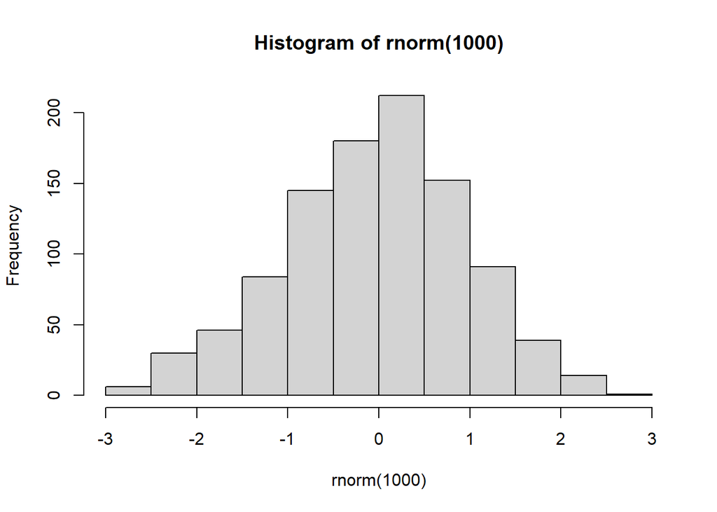

```r
hist(rnorm(1000))
```

On the right hand side, R shows the plot. You can save this histogram by assigning it to e.g. `hist1`:

```r
hist1 <- hist(rnorm(1000))
```

In the environment pane, you can see `hist1` in the data section. The reason is that R stores `hist1` as a list:

```r
typeof(hist1)
```

```
[1] "list"
```

{ggplot2} is a package that is widely used to create graphs in R. Before using the package we first need to load it into the memory:

```r
library(ggplot2)
```

To illustrate its use, we’ll develop a scatter plot using the `mtcars` data frame where we show `hp` on the x-axis, `mpg` on the y-axis and change the color of the dots in line with the number of cylinders (`cyl`).

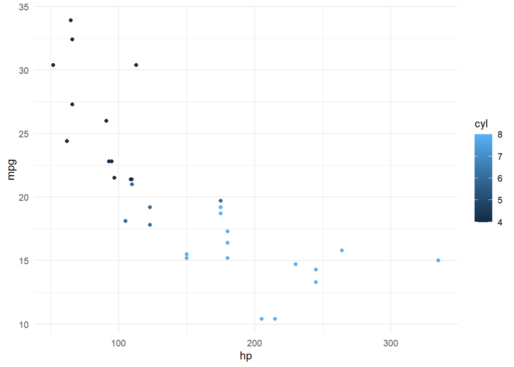

```r
mtcars |>
  ggplot(aes(x = hp, y = mpg, colour = cyl)) +
  geom_point() +
  theme_minimal()
```

The first line starts from the data frame: `mtcars`. Using the pipe operator, that data frame is entered as the first argument of the `ggplot()` function. This is where this function expects the data frame. This data frame (here `mtcars`) is where {ggplot2} will look for the variables. Within `ggplot()` we define what should be on the x-axis, on the y-axis and, if we want to do so, how the color of the dots should change in the `aes()` or aesthetics part. The following two lines tell R to draw a scatter plot and how it should draw the background an other parts of the layout of the plot. We’ll cover {ggplot2} in depth in Chapter 9, Chapter 10 and Chapter 11.

## 2.5 Essential programming structures

We’ll review two essential programming structures: conditional execution and loops. In Chapter 13 we’ll cover these more in depth. We’ll start with conditional execution: a code block is only executed if a condition is met. We’ll then move to loops: repeating the same code a (potentially) large number of times.

### 2.5.1 Conditional execution: `if`-statements

An `if`-statement is used of the execution of code depends on a condition being met. In its simplest form, an `if`-statement is written as

```r
if (condition) {expression}

# Rest of the code
```

If the condition in the brackets `()` is met, then the expression in the curley brackets `{ }` is executed. If that condition is not met, R will continue with the code without executing the expression. A condition is met if the statement is `TRUE`: examples could be `if (a == 2)`, `if (is.numeric(b)`, `if (a < b)`, … ). If the condition is `TRUE`, R will continue and execute the lines of code in `{expression}`. If the condition is `FALSE`, R will continue with the rest of the code and will not execute the lines of code in `{expression}`.

```r
a <- 20
b <- 40
```

Let’s now write the `if`-statement:

```r
if (a < b) {b <- 1000}

print(paste("The value of b is", b))
```

```
[1] "The value of b is 1000"
```

Let’s now change the value of `a` from 20 to 2000, re-use `b`’s original value 40 and rerun the `if`-statement:

```r
a <- 2000
b <- 40

if (a < b) {b <- 1000}

print(paste("The value of b is", b))
```

```
[1] "The value of b is 40"
```

The condition `a < b` now returns `FALSE` and R doesn’t execute the expression `b <- 1000`. In other words, the value of `b` remains 40.

If the expression includes multiple lines, it is good practice to start these lines on a new line and intend the block (RStudio will do so automatically):

```r
if (condition) {

  expression line 1
  expression line 2
  expression line ...

}
```

An `if-else`-statment includes an expression in the case the condition returns `TRUE` as well as an expression in case the condition returns `FALSE`. An `if-else`-statement is written as:

```r
if (condition) {
  expression if TRUE
} else {
  expression if FALSE
}
```

As wast the case with the simple `if`-statement, R evaluates the condition in `(condition)`. If the result is `TRUE`, R continues with the expression in the first curly brackets and it executes the `expression if TRUE`. If the condition in `(condition)` evaluates to `FALSE`, R executes the code in the second curly brackets after the `else` statement and executes the `expression if FALSE`. Note that here, the expressions are usually written on separate lines. The `else` is included in a separate line. This line starts with the last curly bracket from the first statement and ends with the first curly bracket of the second statement.

Let’s build on the simple `if`-statement to illustrate the `if-else` statement. We already know that R should reassign the value of `b` to 1000 if `a < b`. Here we will add what R needs to do in case `a` is larger than or equal to `b`. In the simple `if`-statement, R continued with the rest of the code. Here we will ask R to change the value of `b` to 5000 if `a` is not smaller than `b`. As R completes the statement, it will continue with the rest of the code. Here we will ask R to print the value of `b`.

```r
a <- 20
b <- 40

if (a < b) {
  b <- 1000
} else {
  b <- 5000
}

print(paste("The value of b is", b))
```

```
[1] "The value of b is 1000"
```

R checks if the condition is met, i.e. is `a < b` return `TRUE`. As this is the case, R executes the expression in the first curly brackets: `b <- 1000`. After executing that expression, R continues with the rest of the code. In other words, it doesn’t execute the code in the second expression. Here, the rest of the code asks R to print the value of `b`.

Let’s now change the value of `a` to 2000, reassign the 40 to `b` and run the `if-else`-statement:

```r
a <- 2000
b <- 40

if (a < b) {
  b <- 1000
} else {
  b <- 5000
}

print(paste("The value of b is", b))
```

```
[1] "The value of b is 5000"
```

The condintion is not met (`a < b` returns `FALSE`). R now executes the code in the expression after the `else` statement and reassign the value of 5000 to `b`. The first expression is not executed. After it finishes the second expression, R continues with the rest of the code (`print()`).

**CautionYour turn**

Recall that R interprets “2.5” as a character variable. Suppose that your dataset includes a variable where all numeric variables are read as character variables. However, somethimes that is not the case. To change these variables from character variables in numeric variables, you first test if a variable is a character variable. If that is the case, you change the variable in numeric format and assign it to the same variable name. If the variable is numeric, you can continue with the code. Let’s use `numvar` as the variable to test.

What function would you use to test if `numvar` is a character variable?

```r
is.character(numvar)
```

What function would you use to change the type of `numvar` into numeric in case it is a character variable?

```r
# There are two options:
as.numeric(numvar)
as.double(numvar)
```

Let’s assing a value to `numvar`

```r
numvar <- "2.5"
```

Write the `if`-statement: check if `numvar` is a character variable. If that is the case, change its type to numeric. The rest of the code should multiply the value of numvar with 10, assign and assign the value to `res` and print “The value of res is 25” `print(paste("The value of res is", res))`.

```r
if (is.character(numvar) == TRUE) {numvar <- as.numeric(numvar)}

res <- 10 * numvar

print(paste("The value of res is", res))
```

```
[1] "The value of res is 25"
```

Note that you can shorten this code:

```r
# the condition "is.character(numvar)" evaluates to TRUE or FALSE.
# if.character(numvar) == TRUE actually equals TRUE == TRUE, which is
# obviously TRUE, but you can eliminate the "== TRUE" part.

numvar <- "2.5"
if (is.character(numvar)) {numvar <- as.numeric(numvar)}
```

Let’s change the previous excercise: test if `numvar` is numeric. If that is the case, multiply with 10 and assign the result to `res`. If `numvar` is not numeric, change the type to numeric, multiply the result with 100 and assign the result to `res`. Print the value of `res`.

First, we set the value for `numvar`:

```r
numvar <- "4.5"
```

Write the `if-else`-statement.

```r
if (is.numeric(numvar)) {
  res <- numvar * 10
} else {
  res <- as.numeric(numvar) * 100
}

print(paste("The value of res is", res))
```

```
[1] "The value of res is 450"
```

Use the vector `grades` with values `c(15, 11, 22, 18, 12)`. Check if one of the elements of this vector is larger than 20. If that is the case, print “At least one grade is larger than 20”. If that is not the case, print “All grades are less than or equal to 20”.

How would you write the condition (recall that R is vectorized and that `TRUE` is 1 and `FALSE` is 0)?

```r
# test if a grade is > 20
grades > 20

# this statement returns FALSE if an element is <= 20 and 1 if an element is > 20
# output is e.g. TRUE, FALSE, FALSE, TRUE, FALSE
# TRUE is 1 and FALSE is 0
# sum(TRUE, FALSE, FALSE, TRUE, FALSE) = 2
# if no grades are > 20, the statement evaluates to FALSE for each element
# and the sum of each of these evaluations is 0

# condition
sum(grades > 20) == 0
```

Write the `is-else`-statement

```r
if (sum(grades > 20) == 0) {
  print("All grades are less than or equal to 20.")
} else {
  print("At least one grade is larger than 20.")
}
```

[output not shown]

Rerun you previous code with

```r
grades <- c(10, 12, 15, 18, 8)
```

### 2.5.2 For loop

The simpelest `for` loop is written as

```r
for (i in sequence) {
  expression
}
```

Using a `for` loop, R iterates over a sequence `sequence` and executes the expression `{expression}` each iteration. The expression is included in curly brackets. All lines between these two brackets are executed in each iteration. The code for the expression is intended.

Say the sequence is a sequence starting at 1, ending at 10 in steps of 1 (`1:10`). As the loop starts, R sets the value of `i` equal to 1 and executes the code in the expression. After finishing these lines, changes the value of `i` and sets it equal to the second value in the sequence. This value of 2. Using `i = 2` R executes the expression. After finishing the expression for the second time, R returns to the sequence and changes the value of `i` to 3. This continues until `i` equals the last value in the sequence, e.g. 10. R executes the expression one last time. After completing the expression, R continues with the rest of the code.

To illustrate, we’ll use a sequence `1:5` and ask R to print the value of `i`.

```r
for (i in 1:5) {
  print(paste("The value of i is", i))
}
```

```
[1] "The value of i is 1"
[1] "The value of i is 2"
[1] "The value of i is 3"
[1] "The value of i is 4"
[1] "The value of i is 5"
```

```r
print("R continues with the rest of the code")
```

```
[1] "R continues with the rest of the code"
```

In this loop, the sequence is `1:5`. R enters the loop and sets the value of `i` equal to 1. Using this value, R executes the expression. Here is the expression asks R to print “The value if i is” i. For the first iteration, the result is “The value of i is 1”. After finishing this expression, R returns to the sequence and sets `i` equal to 2, executes the code (prints “The value of i is 2”), returns to the sequence, … . After the last iteration, R continues with the rest of the code and prints “R continues with the rest of the code”.

The sequence doesn’t have to be numeric. In the previous example, we used `i`, but this doesn’t have to be the case. The next for loop illustrates this using the sequence `letters[1:5]` and `abc` as the counter in the loop. Here, `abc` is first set equal to `letters[1]`. The code - `print(abc)` - just asks R to print the value of `abc`:

```r
for (abc in letters[1:5]) {
  print(abc)
}
```

```
[1] "a"
[1] "b"
[1] "c"
[1] "d"
[1] "e"
```

The sequence can be any other vector. The next loop uses the vector `c("dog", "cat", "bird", "fish")` and iterates over each element. We just `pet´ as the counter. The expression prints “my pet is a” with the result of the iteration:

```r
for (pet in c("dog", "cat", "bird", "fish")) {
  print(paste("My pet is a", pet))
}
```

```
[1] "My pet is a dog"
[1] "My pet is a cat"
[1] "My pet is a bird"
[1] "My pet is a fish"
```

**CautionYour turn**

```r
exams <- c("Financial statement analysis", "Marketing")
res_ex <- c(12, 14)

for (i in 1:2) {
  print(paste("The result for my", exams[i], "was", res_ex[i]))
  }
```

```
[1] "The result for my Financial statement analysis was 12"
[1] "The result for my Marketing was 14"
```

A `for` loop is often used to run simulations. Let’s try to simulate the probability that you pass a multiple choice examen where each question has 4 options, a, b, c, d and there are 48 questions. The result on the exam is equal to the number of correct answers - 8 and rescaled to 20.

Let’s first set up the parameters of the simulation. The exam has 48 questions with 4 possible answers: a, b, c and d. Use `sample()` to select 48 random draws from a, b, c, and d and assign the result to the object `correct`.

```r
correct <- sample(letters[1:4], size = 48, replace = TRUE)
```

Second, let’s set the parameters for this simulation. We’ll run `n = 10000` simulations. In each iteration we’ll calculate the score. To store the score you need a vector `results`. Assign the value of 10000 to `n` and create an empty numeric vector with of length `n`.

```r
n <- 10000L
results <- vector(mode = "numeric", length = n)
```

Let’s now run the simulation. Suppose that a student “gambles” all answers. This is as if the student draws at random letters from a, b, c and d to select to answer. In other words, the answer is also a random draw from a, b, c, d. We’ll change this random draw in each simulation and compare the with correct result. Using `answer` to store the answer, we can compare `answer` with the correct answer using `answer == correct`. The result is `TRUE` if the ith element in answer is equal to the ith element in correct, else it is `FALSE`. Using the fact that the `TRUE` is 1 and `FALSE` is 0, we can calculate the number of good answers as `sum(answer == correct)`. The final result equals this sum, minus 8 divided by 2. We can calculate that final result after the `for` loop.

Set up de `for` loop: use `sample()` to select at random 48 values from a, b, c and d and assign the outcome to `answer`. Calculate the total number of answers where the answer equals the correct answer and store that number in the `results` vector.

```r
for (i in 1:n) {
  answer <- sample(letters[1:4], size = 48, replace = TRUE)
  results[i] <- sum(answer == correct)
}
```

Now calculate the final result: subtract 8 from the results and divide by 2

```r
results <- (results - 8) / 2
```

What is the mean, the minimum and maximum score for these 10000 exams? For calculate the minimum, you can use `min()`; for the maximum you can use `max()`:

```r
mean(results)
min(results)
max(results)
```

Can you show a histogram if these results?

```r
hist(results)
```

Can you calculate how many exam would have a grade sufficient to tolerate (> 8)?

```r
sum(results > 8)
```

## 2.6 Scripts

Writing code is one thing, remembering why you wrote something the way you did is another. In addition, if you need to share code with others, it is useful is your code is easy to read. Comments and sections allow you to inform others as well as the future your and structure your code.

In the editor, write the following lines:

```r
# A comment
6 + 6
```

```
[1] 12
```

```r
7 + 7
```

```
[1] 14
```

```r
# A second comment
8 + 8
```

```
[1] 16
```

```r
9 + 9
```

```
[1] 18
```

The console shows the output:

```
> # A comment
> 6 + 6
[1] 12 >
7 + 7
[1] 14
>
> # A second comment
> 8 + 8
[1] 16
> 9 + 9
[1] 18
```

As you would expect, the console shows all lines of code. However, notice that the lines starting with `#` are shown in the console but didn’t produce any other result. The `#` tells R that it doesn’t have to execute that line. If you have multiple lines, you need to add a `#` before every line. This very useful if you want to add comments to your code.

```r
# The next lines execute code to do something
# They calculate the difference between two values
10 - 9
```

```
[1] 1
```

```r
9 - 8
```

```
[1] 1
```

```r
8 - 7
```

```
[1] 1
```

```r
# The next lines execute code to do something else
# They calculate the sum of two values
10 + 9
```

```
[1] 19
```

```r
9 + 8
```

```
[1] 17
```

```r
8 + 7
```

```
[1] 15
```

Comments are extremely important. They make your code readable. If you write code, you will often use a script multiple times and/or you will share it with others. Adding comments to your code helps you to remember what you did, why you did it and how you did it. If you need to re-use the code in the future or if you have to extend the code at some later date, these comments will often be very helpful if you meet lines in your code where you don’t recall why you wrote the code the way you did. If you share your code with others, comments explain your code.

Note that you don’t need to add comments before a line. You can also add a comment after a line:

```r
11 - 10 #Calculate difference between 11 and 10
```

```
[1] 1
```

You can also use `#` to comment out code: to temporarily disable lines of code without deleting them. You would usually do this to test parts of the code. In the next example, the first two lines will not be executed:

```r
# 10 + 9
# 9 + 8
8 + 7
```

```
[1] 15
```

To comment out various lines of code: select the lines and press Ctrl + shift + C (Command + shift + C). You can do the same if you want to remove the `#` from these lines of code.

If you code is long but you don’t want to split is up in various scripts, you can use `#` to create sections and subsections in your code. If you add 4 `#` at the end of a comment line, RStudio creates a section. RStudio would do the same is you end with 4 `-`’s. To create a subsection, start with `##` and end with 4 `#`. You can add a name between the opening and closing hashtags. Here is an example:

```r
# name of section 1: Importing data ####

# comment line: what is the purpose, ...

2 + 2
```

```
[1] 4
```

```r
## name of subsection: Importing xls files and saving as R datafiles ####

# comment line: what is the purpose and how readr_xls

3 + 3
```

```
[1] 6
```

```r
## name of subsection: Importing csv files ####

# comment line: wat is the purpose and how readr_csv

4 + 4
```

```
[1] 8
```

```r
### name of sub-subsection: unnecessary columns ####

### name of sub-sub section: saving as R datafiles ####

# name of section 2: Data wranging ####

## name of subsection: tidying ####

## name of subsection: transformation ####
```

Notice that the editor now shows a small triangle next to the line number. If you click on that triangle, the section collapses. If you click on the arrow again, the section expands. These sections help you to add a structure to your code. In addition, they make it easier to scroll through the script in case you need to change specific parts of the code. In R studio, you can see the document outline if you use Ctrl + shift + O (Command + Shift + O) or if you follow `Code` and `Show document outline` from the file menu.

Sections are helpful if your code is long but not too long. If your code is long, it is preferable to split your code in various scripts and run these scripts. If you need to run a script, you can use the `source()` command. To illustrate: open a new file and type

```r
print("hello world")
```

```
[1] "hello world"
```

```r
a <- pi
print(round(a, digits = 2))
```

```
[1] 3.14
```

and save as `example_script.R` you can reuse the script in your workflow. There are two ways to do to: first open the file and run all lines. Second, using the `source()` function and including the name of the script, R will run your script. For instance, close the script `example_script.R`, open a new file and type:

```r
source("example_script.R")
```

In the console, you’ll see that R prints “Hello world” and “3.14”.

This is very useful is larger workflows as you can distribute various steps of the flow in multiple smaller scripts, e.g. one that you use to import the data, one to clean and transform the data, one where you do some exploratory data plotting, one that includes your analysis and one that includes the plots and tables you will include in your report of paper. Long scripts are often very difficult to navigate. Using a multiple scripts for multiple tasks makes it easier to see where you are in your workflow.

Bache, Stefan Milton, and Hadley Wickham. 2022. *Magrittr: A Forward-Pipe Operator for r*.

Wickham, Hadley, Romain François, Lionel Henry, Kirill Müller, and Davis Vaughan. 2023. *Dplyr: A Grammar of Data Manipulation*. https://dplyr.tidyverse.org.